# Risk Factor Analysis

## Outcome Variable

**Outcome Variable:** ever_stunted

## Predictor Variables

**Intervention Variable:** pers_wast

**Adjustment Set:**

- arm
- sex
- W_mage
- meducyrs
- month
- brthmon
- W_parity
- delta_W_mage
- delta_meducyrs
- delta_month
- delta_brthmon
- delta_W_parity

## Stratifying Variables

The analysis was stratified on these variable(s):

- agecat
- studyid
- country

## Data Summary

| agecat | studyid | country | pers_wast | ever_stunted | n_cell | n |
| --- | --- | --- | --- | --- | --- | --- |
| 0-24 months (no birth st.) | ki0047075b-MAL-ED | BANGLADESH | 0 | 0 | 98 | 217 |
| 0-24 months (no birth st.) | ki0047075b-MAL-ED | BANGLADESH | 0 | 1 | 112 | 217 |
| 0-24 months (no birth st.) | ki0047075b-MAL-ED | BANGLADESH | 1 | 0 | 6 | 217 |
| 0-24 months (no birth st.) | ki0047075b-MAL-ED | BANGLADESH | 1 | 1 | 1 | 217 |
| 0-24 months (no birth st.) | ki0047075b-MAL-ED | BRAZIL | 0 | 0 | 178 | 208 |
| 0-24 months (no birth st.) | ki0047075b-MAL-ED | BRAZIL | 0 | 1 | 29 | 208 |
| 0-24 months (no birth st.) | ki0047075b-MAL-ED | BRAZIL | 1 | 0 | 1 | 208 |
| 0-24 months (no birth st.) | ki0047075b-MAL-ED | BRAZIL | 1 | 1 | 0 | 208 |
| 0-24 months (no birth st.) | ki0047075b-MAL-ED | INDIA | 0 | 0 | 89 | 209 |
| 0-24 months (no birth st.) | ki0047075b-MAL-ED | INDIA | 0 | 1 | 101 | 209 |
| 0-24 months (no birth st.) | ki0047075b-MAL-ED | INDIA | 1 | 0 | 12 | 209 |
| 0-24 months (no birth st.) | ki0047075b-MAL-ED | INDIA | 1 | 1 | 7 | 209 |
| 0-24 months (no birth st.) | ki0047075b-MAL-ED | NEPAL | 0 | 0 | 153 | 212 |
| 0-24 months (no birth st.) | ki0047075b-MAL-ED | NEPAL | 0 | 1 | 54 | 212 |
| 0-24 months (no birth st.) | ki0047075b-MAL-ED | NEPAL | 1 | 0 | 4 | 212 |
| 0-24 months (no birth st.) | ki0047075b-MAL-ED | NEPAL | 1 | 1 | 1 | 212 |
| 0-24 months (no birth st.) | ki0047075b-MAL-ED | PERU | 0 | 0 | 115 | 266 |
| 0-24 months (no birth st.) | ki0047075b-MAL-ED | PERU | 0 | 1 | 151 | 266 |
| 0-24 months (no birth st.) | ki0047075b-MAL-ED | PERU | 1 | 0 | 0 | 266 |
| 0-24 months (no birth st.) | ki0047075b-MAL-ED | PERU | 1 | 1 | 0 | 266 |
| 0-24 months (no birth st.) | ki0047075b-MAL-ED | SOUTH AFRICA | 0 | 0 | 136 | 280 |
| 0-24 months (no birth st.) | ki0047075b-MAL-ED | SOUTH AFRICA | 0 | 1 | 137 | 280 |
| 0-24 months (no birth st.) | ki0047075b-MAL-ED | SOUTH AFRICA | 1 | 0 | 7 | 280 |
| 0-24 months (no birth st.) | ki0047075b-MAL-ED | SOUTH AFRICA | 1 | 1 | 0 | 280 |
| 0-24 months (no birth st.) | ki0047075b-MAL-ED | TANZANIA, UNITED REPUBLIC OF | 0 | 0 | 41 | 219 |
| 0-24 months (no birth st.) | ki0047075b-MAL-ED | TANZANIA, UNITED REPUBLIC OF | 0 | 1 | 178 | 219 |
| 0-24 months (no birth st.) | ki0047075b-MAL-ED | TANZANIA, UNITED REPUBLIC OF | 1 | 0 | 0 | 219 |
| 0-24 months (no birth st.) | ki0047075b-MAL-ED | TANZANIA, UNITED REPUBLIC OF | 1 | 1 | 0 | 219 |
| 0-24 months (no birth st.) | ki1000108-CMC-V-BCS-2002 | INDIA | 0 | 0 | 24 | 293 |
| 0-24 months (no birth st.) | ki1000108-CMC-V-BCS-2002 | INDIA | 0 | 1 | 228 | 293 |

[output cut: 198 more lines]

The following strata were considered:

- agecat: 0-24 months (no birth st.), studyid: ki0047075b-MAL-ED, country: BANGLADESH
- agecat: 0-24 months (no birth st.), studyid: ki0047075b-MAL-ED, country: BRAZIL
- agecat: 0-24 months (no birth st.), studyid: ki0047075b-MAL-ED, country: INDIA
- agecat: 0-24 months (no birth st.), studyid: ki0047075b-MAL-ED, country: NEPAL
- agecat: 0-24 months (no birth st.), studyid: ki0047075b-MAL-ED, country: PERU
- agecat: 0-24 months (no birth st.), studyid: ki0047075b-MAL-ED, country: SOUTH AFRICA
- agecat: 0-24 months (no birth st.), studyid: ki0047075b-MAL-ED, country: TANZANIA, UNITED REPUBLIC OF
- agecat: 0-24 months (no birth st.), studyid: ki1000108-CMC-V-BCS-2002, country: INDIA
- agecat: 0-24 months (no birth st.), studyid: ki1000108-IRC, country: INDIA
- agecat: 0-24 months (no birth st.), studyid: ki1000109-EE, country: PAKISTAN
- agecat: 0-24 months (no birth st.), studyid: ki1000109-ResPak, country: PAKISTAN
- agecat: 0-24 months (no birth st.), studyid: ki1017093b-PROVIDE, country: BANGLADESH
- agecat: 0-24 months (no birth st.), studyid: ki1066203-TanzaniaChild2, country: TANZANIA, UNITED REPUBLIC OF
- agecat: 0-24 months (no birth st.), studyid: ki1101329-Keneba, country: GAMBIA
- agecat: 0-24 months (no birth st.), studyid: ki1112895-Guatemala BSC, country: GUATEMALA
- agecat: 0-24 months (no birth st.), studyid: ki1113344-GMS-Nepal, country: NEPAL
- agecat: 0-24 months (no birth st.), studyid: ki1114097-CMIN, country: BANGLADESH
- agecat: 0-24 months (no birth st.), studyid: ki1114097-CMIN, country: PERU
- agecat: 0-24 months (no birth st.), studyid: ki1114097-CONTENT, country: PERU
- agecat: 0-6 months (no birth st.), studyid: ki0047075b-MAL-ED, country: BANGLADESH
- agecat: 0-6 months (no birth st.), studyid: ki0047075b-MAL-ED, country: BRAZIL
- agecat: 0-6 months (no birth st.), studyid: ki0047075b-MAL-ED, country: INDIA
- agecat: 0-6 months (no birth st.), studyid: ki0047075b-MAL-ED, country: NEPAL
- agecat: 0-6 months (no birth st.), studyid: ki0047075b-MAL-ED, country: PERU
- agecat: 0-6 months (no birth st.), studyid: ki0047075b-MAL-ED, country: SOUTH AFRICA
- agecat: 0-6 months (no birth st.), studyid: ki0047075b-MAL-ED, country: TANZANIA, UNITED REPUBLIC OF
- agecat: 0-6 months (no birth st.), studyid: ki1000108-CMC-V-BCS-2002, country: INDIA
- agecat: 0-6 months (no birth st.), studyid: ki1000108-IRC, country: INDIA
- agecat: 0-6 months (no birth st.), studyid: ki1000109-EE, country: PAKISTAN
- agecat: 0-6 months (no birth st.), studyid: ki1000109-ResPak, country: PAKISTAN
- agecat: 0-6 months (no birth st.), studyid: ki1017093b-PROVIDE, country: BANGLADESH
- agecat: 0-6 months (no birth st.), studyid: ki1066203-TanzaniaChild2, country: TANZANIA, UNITED REPUBLIC OF
- agecat: 0-6 months (no birth st.), studyid: ki1101329-Keneba, country: GAMBIA
- agecat: 0-6 months (no birth st.), studyid: ki1112895-Guatemala BSC, country: GUATEMALA
- agecat: 0-6 months (no birth st.), studyid: ki1113344-GMS-Nepal, country: NEPAL
- agecat: 0-6 months (no birth st.), studyid: ki1114097-CMIN, country: BANGLADESH
- agecat: 0-6 months (no birth st.), studyid: ki1114097-CMIN, country: PERU
- agecat: 0-6 months (no birth st.), studyid: ki1114097-CONTENT, country: PERU
- agecat: 6-24 months, studyid: ki0047075b-MAL-ED, country: BANGLADESH
- agecat: 6-24 months, studyid: ki0047075b-MAL-ED, country: BRAZIL
- agecat: 6-24 months, studyid: ki0047075b-MAL-ED, country: INDIA
- agecat: 6-24 months, studyid: ki0047075b-MAL-ED, country: NEPAL
- agecat: 6-24 months, studyid: ki0047075b-MAL-ED, country: PERU
- agecat: 6-24 months, studyid: ki0047075b-MAL-ED, country: SOUTH AFRICA
- agecat: 6-24 months, studyid: ki0047075b-MAL-ED, country: TANZANIA, UNITED REPUBLIC OF
- agecat: 6-24 months, studyid: ki1000108-CMC-V-BCS-2002, country: INDIA
- agecat: 6-24 months, studyid: ki1000108-IRC, country: INDIA
- agecat: 6-24 months, studyid: ki1000109-EE, country: PAKISTAN
- agecat: 6-24 months, studyid: ki1000109-ResPak, country: PAKISTAN
- agecat: 6-24 months, studyid: ki1017093b-PROVIDE, country: BANGLADESH
- agecat: 6-24 months, studyid: ki1066203-TanzaniaChild2, country: TANZANIA, UNITED REPUBLIC OF
- agecat: 6-24 months, studyid: ki1101329-Keneba, country: GAMBIA
- agecat: 6-24 months, studyid: ki1112895-Guatemala BSC, country: GUATEMALA
- agecat: 6-24 months, studyid: ki1113344-GMS-Nepal, country: NEPAL
- agecat: 6-24 months, studyid: ki1114097-CMIN, country: BANGLADESH
- agecat: 6-24 months, studyid: ki1114097-CMIN, country: PERU
- agecat: 6-24 months, studyid: ki1114097-CONTENT, country: PERU

### Dropped Strata

Some strata were dropped due to rare outcomes:

- agecat: 0-24 months (no birth st.), studyid: ki0047075b-MAL-ED, country: BANGLADESH
- agecat: 0-24 months (no birth st.), studyid: ki0047075b-MAL-ED, country: BRAZIL
- agecat: 0-24 months (no birth st.), studyid: ki0047075b-MAL-ED, country: NEPAL
- agecat: 0-24 months (no birth st.), studyid: ki0047075b-MAL-ED, country: PERU
- agecat: 0-24 months (no birth st.), studyid: ki0047075b-MAL-ED, country: SOUTH AFRICA
- agecat: 0-24 months (no birth st.), studyid: ki0047075b-MAL-ED, country: TANZANIA, UNITED REPUBLIC OF
- agecat: 0-24 months (no birth st.), studyid: ki1000108-CMC-V-BCS-2002, country: INDIA
- agecat: 0-24 months (no birth st.), studyid: ki1000109-EE, country: PAKISTAN
- agecat: 0-24 months (no birth st.), studyid: ki1112895-Guatemala BSC, country: GUATEMALA
- agecat: 0-24 months (no birth st.), studyid: ki1114097-CMIN, country: BANGLADESH
- agecat: 0-24 months (no birth st.), studyid: ki1114097-CONTENT, country: PERU
- agecat: 0-6 months (no birth st.), studyid: ki0047075b-MAL-ED, country: BANGLADESH
- agecat: 0-6 months (no birth st.), studyid: ki0047075b-MAL-ED, country: BRAZIL
- agecat: 0-6 months (no birth st.), studyid: ki0047075b-MAL-ED, country: NEPAL
- agecat: 0-6 months (no birth st.), studyid: ki0047075b-MAL-ED, country: PERU
- agecat: 0-6 months (no birth st.), studyid: ki0047075b-MAL-ED, country: SOUTH AFRICA
- agecat: 0-6 months (no birth st.), studyid: ki0047075b-MAL-ED, country: TANZANIA, UNITED REPUBLIC OF
- agecat: 0-6 months (no birth st.), studyid: ki1112895-Guatemala BSC, country: GUATEMALA
- agecat: 0-6 months (no birth st.), studyid: ki1114097-CMIN, country: BANGLADESH
- agecat: 0-6 months (no birth st.), studyid: ki1114097-CONTENT, country: PERU
- agecat: 6-24 months, studyid: ki0047075b-MAL-ED, country: BANGLADESH
- agecat: 6-24 months, studyid: ki0047075b-MAL-ED, country: BRAZIL
- agecat: 6-24 months, studyid: ki0047075b-MAL-ED, country: INDIA
- agecat: 6-24 months, studyid: ki0047075b-MAL-ED, country: NEPAL
- agecat: 6-24 months, studyid: ki0047075b-MAL-ED, country: PERU
- agecat: 6-24 months, studyid: ki0047075b-MAL-ED, country: SOUTH AFRICA
- agecat: 6-24 months, studyid: ki0047075b-MAL-ED, country: TANZANIA, UNITED REPUBLIC OF
- agecat: 6-24 months, studyid: ki1000108-CMC-V-BCS-2002, country: INDIA
- agecat: 6-24 months, studyid: ki1000109-EE, country: PAKISTAN
- agecat: 6-24 months, studyid: ki1000109-ResPak, country: PAKISTAN
- agecat: 6-24 months, studyid: ki1017093b-PROVIDE, country: BANGLADESH
- agecat: 6-24 months, studyid: ki1112895-Guatemala BSC, country: GUATEMALA
- agecat: 6-24 months, studyid: ki1114097-CMIN, country: BANGLADESH
- agecat: 6-24 months, studyid: ki1114097-CMIN, country: PERU
- agecat: 6-24 months, studyid: ki1114097-CONTENT, country: PERU

## Methods Detail

We’re interested in the causal parameters $E[Y_a]$ for all values of $a \in \mathcal{A}$. These parameters represent the mean outcome if, possibly contrary to fact, we intervened to set all units to have $A=a$. Under the randomization and positivity assumptions, these are identified by the statistical parameters $\psi_a=E_W[E_{Y|A,W}(Y|A=a,W)]$. In addition, we’re interested in the mean of $Y$, $E[Y]$ under no intervention (the observed mean). We will estimate these parameters by using SuperLearner to fit the relevant likelihood factors – $E_{Y|A,W}(Y|A=a,W)$ and $p(A=a|W)$, and then updating our likelihood fit using a joint TMLE.

For unadjusted analyses ($W=\{\}$), initial likelihoods were estimated using Lrnr_glm to estimate the simple $E(Y|A)$ and Lrnr_mean to estimate $p(A)$. For adjusted analyses, a small library containing Lrnr_glmnet, Lrnr_xgboost, and Lrnr_mean was used.

Having estimated these parameters, we will then use the delta method to estimate relative risks and attributable risks relative to a prespecified baseline level of $A$.

# Results Detail

## Results Plots

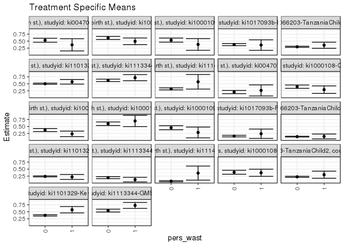

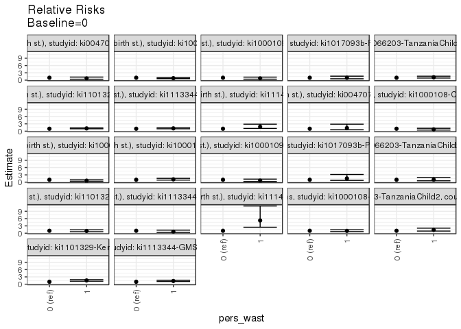

[figure not shown]

[figure not shown]

## Results Table

### Parameter: TSM

| agecat | studyid | country | intervention_level | baseline_level | estimate | ci_lower | ci_upper |
| --- | --- | --- | --- | --- | --- | --- | --- |
| 0-24 months (no birth st.) | ki0047075b-MAL-ED | INDIA | 0 | NA | 0.5315789 | 0.4604552 | 0.6027027 |
| 0-24 months (no birth st.) | ki0047075b-MAL-ED | INDIA | 1 | NA | 0.3684211 | 0.1510014 | 0.5858407 |
| 0-24 months (no birth st.) | ki1000108-IRC | INDIA | 0 | NA | 0.6139064 | 0.5584110 | 0.6694018 |
| 0-24 months (no birth st.) | ki1000108-IRC | INDIA | 1 | NA | 0.4928403 | 0.3742779 | 0.6114028 |
| 0-24 months (no birth st.) | ki1000109-ResPak | PAKISTAN | 0 | NA | 0.5359116 | 0.4630777 | 0.6087455 |
| 0-24 months (no birth st.) | ki1000109-ResPak | PAKISTAN | 1 | NA | 0.3809524 | 0.1727367 | 0.5891681 |
| 0-24 months (no birth st.) | ki1017093b-PROVIDE | BANGLADESH | 0 | NA | 0.3760263 | 0.3375251 | 0.4145275 |
| 0-24 months (no birth st.) | ki1017093b-PROVIDE | BANGLADESH | 1 | NA | 0.3600000 | 0.1716949 | 0.5483051 |
| 0-24 months (no birth st.) | ki1066203-TanzaniaChild2 | TANZANIA, UNITED REPUBLIC OF | 0 | NA | 0.2983676 | 0.2791223 | 0.3176129 |
| 0-24 months (no birth st.) | ki1066203-TanzaniaChild2 | TANZANIA, UNITED REPUBLIC OF | 1 | NA | 0.3528895 | 0.2438095 | 0.4619696 |
| 0-24 months (no birth st.) | ki1101329-Keneba | GAMBIA | 0 | NA | 0.5015996 | 0.4805743 | 0.5226249 |
| 0-24 months (no birth st.) | ki1101329-Keneba | GAMBIA | 1 | NA | 0.5709723 | 0.4890216 | 0.6529229 |
| 0-24 months (no birth st.) | ki1113344-GMS-Nepal | NEPAL | 0 | NA | 0.6220805 | 0.5782753 | 0.6658856 |
| 0-24 months (no birth st.) | ki1113344-GMS-Nepal | NEPAL | 1 | NA | 0.7187302 | 0.6092379 | 0.8282225 |
| 0-24 months (no birth st.) | ki1114097-CMIN | PERU | 0 | NA | 0.3183230 | 0.2823183 | 0.3543276 |
| 0-24 months (no birth st.) | ki1114097-CMIN | PERU | 1 | NA | 0.5714286 | 0.3120065 | 0.8308506 |
| 0-6 months (no birth st.) | ki0047075b-MAL-ED | INDIA | 0 | NA | 0.2052632 | 0.1476953 | 0.2628310 |
| 0-6 months (no birth st.) | ki0047075b-MAL-ED | INDIA | 1 | NA | 0.2631579 | 0.0646818 | 0.4616340 |
| 0-6 months (no birth st.) | ki1000108-CMC-V-BCS-2002 | INDIA | 0 | NA | 0.3971235 | 0.3366646 | 0.4575825 |
| 0-6 months (no birth st.) | ki1000108-CMC-V-BCS-2002 | INDIA | 1 | NA | 0.2909701 | 0.1568246 | 0.4251157 |
| 0-6 months (no birth st.) | ki1000108-IRC | INDIA | 0 | NA | 0.3718863 | 0.3169594 | 0.4268132 |
| 0-6 months (no birth st.) | ki1000108-IRC | INDIA | 1 | NA | 0.2356282 | 0.1370443 | 0.3342122 |
| 0-6 months (no birth st.) | ki1000109-EE | PAKISTAN | 0 | NA | 0.5968335 | 0.5330743 | 0.6605928 |
| 0-6 months (no birth st.) | ki1000109-EE | PAKISTAN | 1 | NA | 0.6951988 | 0.4945742 | 0.8958233 |
| 0-6 months (no birth st.) | ki1000109-ResPak | PAKISTAN | 0 | NA | 0.4530387 | 0.3803390 | 0.5257383 |
| 0-6 months (no birth st.) | ki1000109-ResPak | PAKISTAN | 1 | NA | 0.2857143 | 0.0920194 | 0.4794091 |
| 0-6 months (no birth st.) | ki1017093b-PROVIDE | BANGLADESH | 0 | NA | 0.1559934 | 0.1271526 | 0.1848343 |
| 0-6 months (no birth st.) | ki1017093b-PROVIDE | BANGLADESH | 1 | NA | 0.2400000 | 0.0724543 | 0.4075457 |
| 0-6 months (no birth st.) | ki1066203-TanzaniaChild2 | TANZANIA, UNITED REPUBLIC OF | 0 | NA | 0.1367403 | 0.1222881 | 0.1511925 |
| 0-6 months (no birth st.) | ki1066203-TanzaniaChild2 | TANZANIA, UNITED REPUBLIC OF | 1 | NA | 0.1428571 | 0.0564295 | 0.2292848 |
| 0-6 months (no birth st.) | ki1101329-Keneba | GAMBIA | 0 | NA | 0.2390694 | 0.2211341 | 0.2570046 |
| 0-6 months (no birth st.) | ki1101329-Keneba | GAMBIA | 1 | NA | 0.2197393 | 0.1315809 | 0.3078977 |
| 0-6 months (no birth st.) | ki1113344-GMS-Nepal | NEPAL | 0 | NA | 0.1953567 | 0.1595198 | 0.2311936 |
| 0-6 months (no birth st.) | ki1113344-GMS-Nepal | NEPAL | 1 | NA | 0.1248731 | 0.0437698 | 0.2059763 |
| 0-6 months (no birth st.) | ki1114097-CMIN | PERU | 0 | NA | 0.0683230 | 0.0488222 | 0.0878237 |
| 0-6 months (no birth st.) | ki1114097-CMIN | PERU | 1 | NA | 0.3571429 | 0.1059585 | 0.6083272 |
| 6-24 months | ki1000108-IRC | INDIA | 0 | NA | 0.3876805 | 0.3178141 | 0.4575469 |
| 6-24 months | ki1000108-IRC | INDIA | 1 | NA | 0.3698627 | 0.2430252 | 0.4967003 |
| 6-24 months | ki1066203-TanzaniaChild2 | TANZANIA, UNITED REPUBLIC OF | 0 | NA | 0.2247135 | 0.2040029 | 0.2454241 |
| 6-24 months | ki1066203-TanzaniaChild2 | TANZANIA, UNITED REPUBLIC OF | 1 | NA | 0.3011297 | 0.1748605 | 0.4273989 |
| 6-24 months | ki1101329-Keneba | GAMBIA | 0 | NA | 0.3714702 | 0.3472711 | 0.3956694 |
| 6-24 months | ki1101329-Keneba | GAMBIA | 1 | NA | 0.5723220 | 0.4586062 | 0.6860379 |
| 6-24 months | ki1113344-GMS-Nepal | NEPAL | 0 | NA | 0.5418854 | 0.4913890 | 0.5923818 |
| 6-24 months | ki1113344-GMS-Nepal | NEPAL | 1 | NA | 0.7263180 | 0.6212289 | 0.8314072 |

### Parameter: E(Y)

| agecat | studyid | country | intervention_level | baseline_level | estimate | ci_lower | ci_upper |
| --- | --- | --- | --- | --- | --- | --- | --- |
| 0-24 months (no birth st.) | ki0047075b-MAL-ED | INDIA | NA | NA | 0.5167464 | 0.4488350 | 0.5846578 |
| 0-24 months (no birth st.) | ki1000108-IRC | INDIA | NA | NA | 0.5916667 | 0.5408218 | 0.6425115 |
| 0-24 months (no birth st.) | ki1000109-ResPak | PAKISTAN | NA | NA | 0.5198020 | 0.4507336 | 0.5888704 |
| 0-24 months (no birth st.) | ki1017093b-PROVIDE | BANGLADESH | NA | NA | 0.3753943 | 0.3376725 | 0.4131162 |
| 0-24 months (no birth st.) | ki1066203-TanzaniaChild2 | TANZANIA, UNITED REPUBLIC OF | NA | NA | 0.2988814 | 0.2798990 | 0.3178639 |
| 0-24 months (no birth st.) | ki1101329-Keneba | GAMBIA | NA | NA | 0.5044763 | 0.4837388 | 0.5252138 |
| 0-24 months (no birth st.) | ki1113344-GMS-Nepal | NEPAL | NA | NA | 0.6336449 | 0.5927799 | 0.6745099 |
| 0-24 months (no birth st.) | ki1114097-CMIN | PERU | NA | NA | 0.3237082 | 0.2879308 | 0.3594857 |
| 0-6 months (no birth st.) | ki0047075b-MAL-ED | INDIA | NA | NA | 0.2105263 | 0.1551227 | 0.2659300 |
| 0-6 months (no birth st.) | ki1000108-CMC-V-BCS-2002 | INDIA | NA | NA | 0.3835616 | 0.3276935 | 0.4394298 |
| 0-6 months (no birth st.) | ki1000108-IRC | INDIA | NA | NA | 0.3444444 | 0.2952897 | 0.3935992 |
| 0-6 months (no birth st.) | ki1000109-EE | PAKISTAN | NA | NA | 0.6024096 | 0.5415000 | 0.6633193 |
| 0-6 months (no birth st.) | ki1000109-ResPak | PAKISTAN | NA | NA | 0.4356436 | 0.3670959 | 0.5041912 |
| 0-6 months (no birth st.) | ki1017093b-PROVIDE | BANGLADESH | NA | NA | 0.1593060 | 0.1307970 | 0.1878149 |
| 0-6 months (no birth st.) | ki1066203-TanzaniaChild2 | TANZANIA, UNITED REPUBLIC OF | NA | NA | 0.1369128 | 0.1226581 | 0.1511674 |
| 0-6 months (no birth st.) | ki1101329-Keneba | GAMBIA | NA | NA | 0.2412713 | 0.2235253 | 0.2590172 |
| 0-6 months (no birth st.) | ki1113344-GMS-Nepal | NEPAL | NA | NA | 0.1869159 | 0.1538509 | 0.2199809 |
| 0-6 months (no birth st.) | ki1114097-CMIN | PERU | NA | NA | 0.0744681 | 0.0543935 | 0.0945427 |
| 6-24 months | ki1000108-IRC | INDIA | NA | NA | 0.3771186 | 0.3151523 | 0.4390850 |
| 6-24 months | ki1066203-TanzaniaChild2 | TANZANIA, UNITED REPUBLIC OF | NA | NA | 0.2259675 | 0.2054816 | 0.2464534 |
| 6-24 months | ki1101329-Keneba | GAMBIA | NA | NA | 0.3752393 | 0.3512585 | 0.3992201 |
| 6-24 months | ki1113344-GMS-Nepal | NEPAL | NA | NA | 0.5610329 | 0.5138522 | 0.6082135 |

### Parameter: RR

| agecat | studyid | country | intervention_level | baseline_level | estimate | ci_lower | ci_upper |
| --- | --- | --- | --- | --- | --- | --- | --- |
| 0-24 months (no birth st.) | ki0047075b-MAL-ED | INDIA | 0 | 0 | 1.0000000 | 1.0000000 | 1.000000 |
| 0-24 months (no birth st.) | ki0047075b-MAL-ED | INDIA | 1 | 0 | 0.6930693 | 0.3784234 | 1.269332 |
| 0-24 months (no birth st.) | ki1000108-IRC | INDIA | 0 | 0 | 1.0000000 | 1.0000000 | 1.000000 |
| 0-24 months (no birth st.) | ki1000108-IRC | INDIA | 1 | 0 | 0.8027939 | 0.6212745 | 1.037348 |
| 0-24 months (no birth st.) | ki1000109-ResPak | PAKISTAN | 0 | 0 | 1.0000000 | 1.0000000 | 1.000000 |
| 0-24 months (no birth st.) | ki1000109-ResPak | PAKISTAN | 1 | 0 | 0.7108493 | 0.4047424 | 1.248465 |
| 0-24 months (no birth st.) | ki1017093b-PROVIDE | BANGLADESH | 0 | 0 | 1.0000000 | 1.0000000 | 1.000000 |
| 0-24 months (no birth st.) | ki1017093b-PROVIDE | BANGLADESH | 1 | 0 | 0.9573799 | 0.5618323 | 1.631405 |
| 0-24 months (no birth st.) | ki1066203-TanzaniaChild2 | TANZANIA, UNITED REPUBLIC OF | 0 | 0 | 1.0000000 | 1.0000000 | 1.000000 |
| 0-24 months (no birth st.) | ki1066203-TanzaniaChild2 | TANZANIA, UNITED REPUBLIC OF | 1 | 0 | 1.1827341 | 0.8625343 | 1.621802 |
| 0-24 months (no birth st.) | ki1101329-Keneba | GAMBIA | 0 | 0 | 1.0000000 | 1.0000000 | 1.000000 |
| 0-24 months (no birth st.) | ki1101329-Keneba | GAMBIA | 1 | 0 | 1.1383029 | 0.9807161 | 1.321211 |
| 0-24 months (no birth st.) | ki1113344-GMS-Nepal | NEPAL | 0 | 0 | 1.0000000 | 1.0000000 | 1.000000 |
| 0-24 months (no birth st.) | ki1113344-GMS-Nepal | NEPAL | 1 | 0 | 1.1553654 | 0.9771103 | 1.366140 |
| 0-24 months (no birth st.) | ki1114097-CMIN | PERU | 0 | 0 | 1.0000000 | 1.0000000 | 1.000000 |
| 0-24 months (no birth st.) | ki1114097-CMIN | PERU | 1 | 0 | 1.7951220 | 1.1243517 | 2.866063 |
| 0-6 months (no birth st.) | ki0047075b-MAL-ED | INDIA | 0 | 0 | 1.0000000 | 1.0000000 | 1.000000 |
| 0-6 months (no birth st.) | ki0047075b-MAL-ED | INDIA | 1 | 0 | 1.2820513 | 0.5733807 | 2.866604 |
| 0-6 months (no birth st.) | ki1000108-CMC-V-BCS-2002 | INDIA | 0 | 0 | 1.0000000 | 1.0000000 | 1.000000 |
| 0-6 months (no birth st.) | ki1000108-CMC-V-BCS-2002 | INDIA | 1 | 0 | 0.7326943 | 0.4509139 | 1.190562 |
| 0-6 months (no birth st.) | ki1000108-IRC | INDIA | 0 | 0 | 1.0000000 | 1.0000000 | 1.000000 |
| 0-6 months (no birth st.) | ki1000108-IRC | INDIA | 1 | 0 | 0.6336029 | 0.4064907 | 0.987606 |
| 0-6 months (no birth st.) | ki1000109-EE | PAKISTAN | 0 | 0 | 1.0000000 | 1.0000000 | 1.000000 |
| 0-6 months (no birth st.) | ki1000109-EE | PAKISTAN | 1 | 0 | 1.1648118 | 0.8561791 | 1.584699 |
| 0-6 months (no birth st.) | ki1000109-ResPak | PAKISTAN | 0 | 0 | 1.0000000 | 1.0000000 | 1.000000 |
| 0-6 months (no birth st.) | ki1000109-ResPak | PAKISTAN | 1 | 0 | 0.6306620 | 0.3142235 | 1.265769 |
| 0-6 months (no birth st.) | ki1017093b-PROVIDE | BANGLADESH | 0 | 0 | 1.0000000 | 1.0000000 | 1.000000 |
| 0-6 months (no birth st.) | ki1017093b-PROVIDE | BANGLADESH | 1 | 0 | 1.5385263 | 0.7472545 | 3.167680 |
| 0-6 months (no birth st.) | ki1066203-TanzaniaChild2 | TANZANIA, UNITED REPUBLIC OF | 0 | 0 | 1.0000000 | 1.0000000 | 1.000000 |
| 0-6 months (no birth st.) | ki1066203-TanzaniaChild2 | TANZANIA, UNITED REPUBLIC OF | 1 | 0 | 1.0447330 | 0.5653023 | 1.930767 |
| 0-6 months (no birth st.) | ki1101329-Keneba | GAMBIA | 0 | 0 | 1.0000000 | 1.0000000 | 1.000000 |
| 0-6 months (no birth st.) | ki1101329-Keneba | GAMBIA | 1 | 0 | 0.9191446 | 0.6113776 | 1.381841 |
| 0-6 months (no birth st.) | ki1113344-GMS-Nepal | NEPAL | 0 | 0 | 1.0000000 | 1.0000000 | 1.000000 |
| 0-6 months (no birth st.) | ki1113344-GMS-Nepal | NEPAL | 1 | 0 | 0.6392055 | 0.3254872 | 1.255299 |
| 0-6 months (no birth st.) | ki1114097-CMIN | PERU | 0 | 0 | 1.0000000 | 1.0000000 | 1.000000 |
| 0-6 months (no birth st.) | ki1114097-CMIN | PERU | 1 | 0 | 5.2272727 | 2.4470057 | 11.166455 |
| 6-24 months | ki1000108-IRC | INDIA | 0 | 0 | 1.0000000 | 1.0000000 | 1.000000 |
| 6-24 months | ki1000108-IRC | INDIA | 1 | 0 | 0.9540400 | 0.6475849 | 1.405518 |
| 6-24 months | ki1066203-TanzaniaChild2 | TANZANIA, UNITED REPUBLIC OF | 0 | 0 | 1.0000000 | 1.0000000 | 1.000000 |
| 6-24 months | ki1066203-TanzaniaChild2 | TANZANIA, UNITED REPUBLIC OF | 1 | 0 | 1.3400608 | 0.8723016 | 2.058649 |
| 6-24 months | ki1101329-Keneba | GAMBIA | 0 | 0 | 1.0000000 | 1.0000000 | 1.000000 |
| 6-24 months | ki1101329-Keneba | GAMBIA | 1 | 0 | 1.5406941 | 1.2501623 | 1.898744 |
| 6-24 months | ki1113344-GMS-Nepal | NEPAL | 0 | 0 | 1.0000000 | 1.0000000 | 1.000000 |
| 6-24 months | ki1113344-GMS-Nepal | NEPAL | 1 | 0 | 1.3403536 | 1.1290879 | 1.591150 |

### Parameter: PAR

| agecat | studyid | country | intervention_level | baseline_level | estimate | ci_lower | ci_upper |
| --- | --- | --- | --- | --- | --- | --- | --- |
| 0-24 months (no birth st.) | ki0047075b-MAL-ED | INDIA | 0 | NA | -0.0148325 | -0.0365836 | 0.0069186 |
| 0-24 months (no birth st.) | ki1000108-IRC | INDIA | 0 | NA | -0.0222397 | -0.0465962 | 0.0021168 |
| 0-24 months (no birth st.) | ki1000109-ResPak | PAKISTAN | 0 | NA | -0.0161096 | -0.0399558 | 0.0077365 |
| 0-24 months (no birth st.) | ki1017093b-PROVIDE | BANGLADESH | 0 | NA | -0.0006320 | -0.0082147 | 0.0069508 |
| 0-24 months (no birth st.) | ki1066203-TanzaniaChild2 | TANZANIA, UNITED REPUBLIC OF | 0 | NA | 0.0005138 | -0.0027668 | 0.0037945 |
| 0-24 months (no birth st.) | ki1101329-Keneba | GAMBIA | 0 | NA | 0.0028767 | -0.0004959 | 0.0062493 |
| 0-24 months (no birth st.) | ki1113344-GMS-Nepal | NEPAL | 0 | NA | 0.0115644 | -0.0027651 | 0.0258940 |
| 0-24 months (no birth st.) | ki1114097-CMIN | PERU | 0 | NA | 0.0053852 | -0.0008480 | 0.0116184 |
| 0-6 months (no birth st.) | ki0047075b-MAL-ED | INDIA | 0 | NA | 0.0052632 | -0.0136594 | 0.0241858 |
| 0-6 months (no birth st.) | ki1000108-CMC-V-BCS-2002 | INDIA | 0 | NA | -0.0135619 | -0.0350782 | 0.0079544 |
| 0-6 months (no birth st.) | ki1000108-IRC | INDIA | 0 | NA | -0.0274419 | -0.0493764 | -0.0055073 |
| 0-6 months (no birth st.) | ki1000109-EE | PAKISTAN | 0 | NA | 0.0055761 | -0.0124971 | 0.0236493 |
| 0-6 months (no birth st.) | ki1000109-ResPak | PAKISTAN | 0 | NA | -0.0173951 | -0.0400324 | 0.0052422 |
| 0-6 months (no birth st.) | ki1017093b-PROVIDE | BANGLADESH | 0 | NA | 0.0033126 | -0.0035112 | 0.0101363 |
| 0-6 months (no birth st.) | ki1066203-TanzaniaChild2 | TANZANIA, UNITED REPUBLIC OF | 0 | NA | 0.0001724 | -0.0022980 | 0.0026428 |
| 0-6 months (no birth st.) | ki1101329-Keneba | GAMBIA | 0 | NA | 0.0022019 | -0.0010235 | 0.0054273 |
| 0-6 months (no birth st.) | ki1113344-GMS-Nepal | NEPAL | 0 | NA | -0.0084408 | -0.0192266 | 0.0023449 |
| 0-6 months (no birth st.) | ki1114097-CMIN | PERU | 0 | NA | 0.0061451 | -0.0000911 | 0.0123814 |
| 6-24 months | ki1000108-IRC | INDIA | 0 | NA | -0.0105619 | -0.0422905 | 0.0211668 |
| 6-24 months | ki1066203-TanzaniaChild2 | TANZANIA, UNITED REPUBLIC OF | 0 | NA | 0.0012541 | -0.0022649 | 0.0047730 |
| 6-24 months | ki1101329-Keneba | GAMBIA | 0 | NA | 0.0037691 | -0.0001283 | 0.0076664 |
| 6-24 months | ki1113344-GMS-Nepal | NEPAL | 0 | NA | 0.0191475 | 0.0016014 | 0.0366936 |

### Parameter: PAF

| agecat | studyid | country | intervention_level | baseline_level | estimate | ci_lower | ci_upper |
| --- | --- | --- | --- | --- | --- | --- | --- |
| 0-24 months (no birth st.) | ki0047075b-MAL-ED | INDIA | 0 | NA | -0.0287037 | -0.0718800 | 0.0127334 |
| 0-24 months (no birth st.) | ki1000108-IRC | INDIA | 0 | NA | -0.0375882 | -0.0798466 | 0.0030164 |
| 0-24 months (no birth st.) | ki1000109-ResPak | PAKISTAN | 0 | NA | -0.0309918 | -0.0781408 | 0.0140952 |
| 0-24 months (no birth st.) | ki1017093b-PROVIDE | BANGLADESH | 0 | NA | -0.0016834 | -0.0220882 | 0.0183139 |
| 0-24 months (no birth st.) | ki1066203-TanzaniaChild2 | TANZANIA, UNITED REPUBLIC OF | 0 | NA | 0.0017192 | -0.0093178 | 0.0126355 |
| 0-24 months (no birth st.) | ki1101329-Keneba | GAMBIA | 0 | NA | 0.0057023 | -0.0010108 | 0.0123704 |
| 0-24 months (no birth st.) | ki1113344-GMS-Nepal | NEPAL | 0 | NA | 0.0182506 | -0.0047024 | 0.0406792 |
| 0-24 months (no birth st.) | ki1114097-CMIN | PERU | 0 | NA | 0.0166360 | -0.0028041 | 0.0356994 |
| 0-6 months (no birth st.) | ki0047075b-MAL-ED | INDIA | 0 | NA | 0.0250000 | -0.0690288 | 0.1107583 |
| 0-6 months (no birth st.) | ki1000108-CMC-V-BCS-2002 | INDIA | 0 | NA | -0.0353578 | -0.0930901 | 0.0193253 |
| 0-6 months (no birth st.) | ki1000108-IRC | INDIA | 0 | NA | -0.0796699 | -0.1456726 | -0.0174696 |
| 0-6 months (no birth st.) | ki1000109-EE | PAKISTAN | 0 | NA | 0.0092563 | -0.0212317 | 0.0388341 |
| 0-6 months (no birth st.) | ki1000109-ResPak | PAKISTAN | 0 | NA | -0.0399297 | -0.0934540 | 0.0109746 |
| 0-6 months (no birth st.) | ki1017093b-PROVIDE | BANGLADESH | 0 | NA | 0.0207937 | -0.0228851 | 0.0626073 |
| 0-6 months (no birth st.) | ki1066203-TanzaniaChild2 | TANZANIA, UNITED REPUBLIC OF | 0 | NA | 0.0012593 | -0.0169479 | 0.0191406 |
| 0-6 months (no birth st.) | ki1101329-Keneba | GAMBIA | 0 | NA | 0.0091263 | -0.0043280 | 0.0224004 |
| 0-6 months (no birth st.) | ki1113344-GMS-Nepal | NEPAL | 0 | NA | -0.0451583 | -0.1041847 | 0.0107127 |
| 0-6 months (no birth st.) | ki1114097-CMIN | PERU | 0 | NA | 0.0825200 | -0.0023669 | 0.1602181 |
| 6-24 months | ki1000108-IRC | INDIA | 0 | NA | -0.0280067 | -0.1157723 | 0.0528553 |
| 6-24 months | ki1066203-TanzaniaChild2 | TANZANIA, UNITED REPUBLIC OF | 0 | NA | 0.0055497 | -0.0101429 | 0.0209986 |
| 6-24 months | ki1101329-Keneba | GAMBIA | 0 | NA | 0.0100445 | -0.0004003 | 0.0203802 |
| 6-24 months | ki1113344-GMS-Nepal | NEPAL | 0 | NA | 0.0341290 | 0.0021782 | 0.0650566 |